# BCB420 Assignment 1

Rochelle (Ruoxuan) Wang

25 Feb 2022

This notebook details the workflow producing a clean, normalized dataset.  
Before we start working with data, we need to make sure all required packages are present.

```r
if (!requireNamespace("BiocManager", quietly = TRUE))
  install.packages("BiocManager")

# if (!requireNamespace("GEOmetadb", quietly = TRUE))
#  BiocManager::install("GEOmetadb")
# did not end up using as documented in Journal

if (!requireNamespace("GEOquery", quietly = TRUE))
  BiocManager::install("GEOquery")

if (!requireNamespace("edgeR", quietly = TRUE))
  BiocManager::install("edgeR")

library(BiocManager)
library(GEOmetadb)
library(edgeR)
library(knitr)
```

# Select an Expression Data Set

The dataset GSE157852 was obtained through a search of GEO, as further detailed in my journal. The GEOMetadb package could also be used, but using the webpage made it easier to click through to the paper to explore the topic being investigated.

```r
#GEO accession of selected dataset
geoID <- "GSE157852"
```

Next, we download the expression data from GEO.

# Clean the data and map to HUGO symbols

## 1 - Download the data

```r
#get the GEO description of dataset
if (!exists(gse)) {
  gse <- getGEO(geoID,GSEMatrix=FALSE)
}
```

```
Error in exists(gse) : invalid first argument
```

```r
#general dataset info
info <- Meta(gse)
#gpl info
current_gpl <- names(GPLList(gse))[1]
current_gpl_info <- Meta(getGEO(current_gpl))
```

- **GEO accession number:** GSE157852
- **Publication:** Human Pluripotent Stem Cell-Derived Neural Cells and Brain Organoids Reveal SARS-CoV-2 Neurotropism Predominates in Choroid Plexus Epithelium
- **Platform title and organism:** NextSeq 550 (Homo sapiens)
- **Platform last updated:** Dec 05 2018
- **Submission date:** Sep 11 2020
- **Last updated:** Dec 23 2020
- **Contact address:** 415 Curie Boulevard
- **Contact email:** sarshan.pather@pennmedicine.upenn.edu
- **Contact institute:** University of Pennsylvania

```r
#Number of genes
dim(raw_counts)[1]
```

```
[1] 29755
```

According to the paper and GEO info, there are triplicates of 3 variables: mock infection 72 hours post-infection (hpi), SARS-CoV-2 24 hpi, and SARS-CoV-2 72 hpi samples, corresponding to the column names.

```r
#samples
colnames(raw_counts)
```

[output not shown]

We generalize the conditions into mock and SARS-CoV-2 to represent control and test conditions. We create a vector to identify conditions for each sample, which will be used during normalization. Since the first 3 samples are mock, and the remaining 6 are COVID, all we have to do is:

```r
sample_groups <- c("mock", "mock", "mock",
                   "covid", "covid", "covid",
                   "covid", "covid", "covid") #vector of order of groups
```

We might also just use the two 72 hour conditions for better comparison, depending on the distribution of the data.

## 3 – Map

The dataset already uses HUGO gene symbols as row identifiers, with the exception of loci without identifiers. Nothing can be done about those genes, and they may have significant changes in expression levels, so we will leave them for now. If necessary, we can filter them out later.

## 4 – Clean

To clean the data, we check for outliers, filter out genes that have low counts, and check whether there are any duplicate genes. We use edgeR to filter low counts, and as specified in Lecture 4 (Isserlin, 2022), we “remove features without at least 1 read per million in n of the samples, where n is the size of the smallest group of replicates”. We have 3 samples in each group, so n=3.

### Filter out low counts

```r
#translate counts into counts per million using edgeR
cpms = cpm(raw_counts[,1:9])
rownames(cpms) <- rownames(raw_counts)

# get rid of low counts
keep = rowSums(cpms>1) >=3 # at least 1 read per million in 3 of the samples
filtered_counts = raw_counts[keep,]

#change in dataset
dim(filtered_counts) #new dataset dimensions
dim(raw_counts)[1] - dim(filtered_counts)[1] #genes filtered out
```

[output not shown]

We then check whether any genes are duplicated, in order to see if further processing is needed.

### Check duplicate genes

```r
#Get summarized counts for each gene
summarized_gene_counts <- sort(table(rownames(filtered_counts)), decreasing = TRUE)

#determine whether duplicates exist
which(summarized_gene_counts>1)
```

[output not shown]

# Apply Normalization

This data is from bulk RNA-seq, so we can normalize by distribution, using Trimmed Mean of M-values (TMM), since this method is specialized for RNASeq data.  
We can visualize the effects of normalization using boxplots and density plots.

```r
#Create an edgeR container for filtered data
#Create DGEList object with matrix and defined groups
d = DGEList(counts=filtered_data_matrix, group=sample_groups)
```

```
Error in is.data.frame(counts) : object 'filtered_data_matrix' not found
```

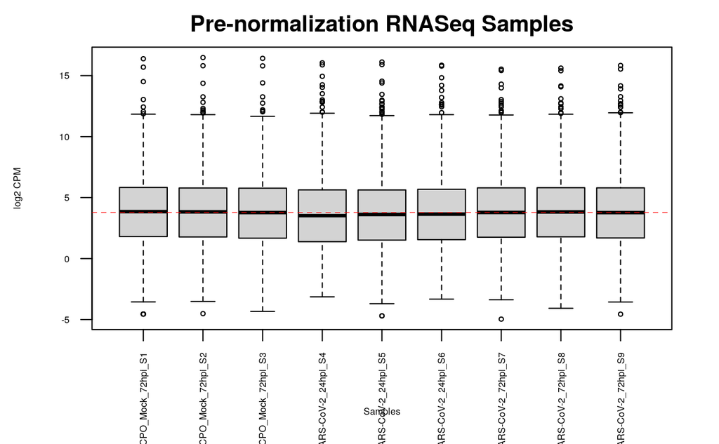

```r
# Boxplot for pre-normalization
predata2plot <- log2(cpm(filtered_counts))
boxplot(predata2plot, xlab = "Samples", ylab = "log2 CPM",
        las = 2, cex = 0.5, cex.lab = 0.5, cex.axis = 0.5,
        main = "Pre-normalization RNASeq Samples")
#draw median on box plot
abline(h = median(apply(predata2plot, 2, median)), col = "red", lwd = 0.6, lty = "dashed")
```

```r
# Boxplot for after normalization
normalized2plot<- log2(cpm(normalized_counts))
boxplot(normalized2plot, xlab = "Samples", ylab = "log2 CPM",
        las = 2, cex = 0.5, cex.lab = 0.5, cex.axis = 0.5,
        main = "Normalized RNASeq Samples")
```

```
Warning in bplt(at[i], wid = width[i], stats = z$stats[, i], out = z$out[z$group ==  :
  Outlier (-Inf) in boxplot 1 is not drawn
Warning in bplt(at[i], wid = width[i], stats = z$stats[, i], out = z$out[z$group ==  :
  Outlier (-Inf) in boxplot 2 is not drawn
Warning in bplt(at[i], wid = width[i], stats = z$stats[, i], out = z$out[z$group ==  :
  Outlier (-Inf) in boxplot 3 is not drawn
Warning in bplt(at[i], wid = width[i], stats = z$stats[, i], out = z$out[z$group ==  :
  Outlier (-Inf) in boxplot 4 is not drawn
Warning in bplt(at[i], wid = width[i], stats = z$stats[, i], out = z$out[z$group ==  :
  Outlier (-Inf) in boxplot 5 is not drawn
Warning in bplt(at[i], wid = width[i], stats = z$stats[, i], out = z$out[z$group ==  :
  Outlier (-Inf) in boxplot 9 is not drawn
```

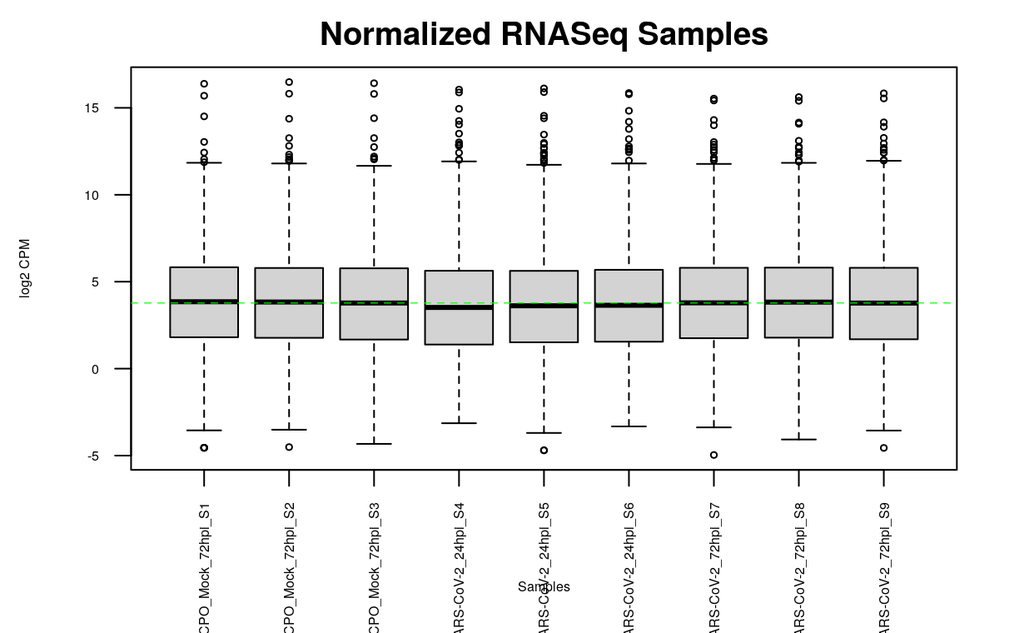

```r
#draw median on box plot
abline(h = median(apply(normalized2plot, 2, median)), col = "green", lwd = 0.6, lty = "dashed")
```

Warnings suggest that there is one outlier in each of boxplots 1, 2, 3, 4, 5, 9 for both pre- and post normalization data. These 6 outliers may need to be removed, but we don’t have reason to believe a measurement error has occurred. Since 3 of the outliers are in the triplicates of the same condition (S1, S2, S3), it is likely that the outliers are valid measurements.  
This, combined with the lack of visible difference between the plots, suggest that this dataset is already normalized. Jacob et al. (2020) state that they have performed TPM normalization and variance stabilizing transformation (VST) using DESeq2 on the raw counts, but since the expression data file is named RawCounts, I assumed that the file contained their pre-normalized data.  
I will visualize using another type of plot to confirm whether there is any change.